# **Plagiarism** in Research & Scientific Writing

Dr. Arun Mitra

[figure not shown]

Three Day workshop on Manuscript Preparation & Research Communication  
3 - 5 June, 2026

## Why this matters, before any definition

**One paper. 1998. *The Lancet*.** Andrew Wakefield linked the MMR vaccine to autism. The data were falsified and the conflicts of interest undisclosed.

Retracted in 2010. But the damage outlived the retraction: collapsing vaccine coverage and **measles outbreaks that continue 25+ years later.**

Closer to home, Indian Vice-Chancellors and senior faculty have been **removed from office** over plagiarism. The UGC wrote its 2018 law *because of* cases like these.

This is not only an ethics issue. It is a career, and a patient-safety, issue.

# This is not abstract

It reaches senior faculty, in India, now.

## A Vice-Chancellor sent to jail

[figure not shown]

The Hindu, 26 November 2014. Former Delhi University V-C Deepak Pental.

## A Vice-Chancellor sacked by the President

[figure not shown]

The Times of India, 30 June 2016. Pondicherry University.

## A Vice-Chancellor under CBI probe

[figure not shown]

ThePrint, 31 January 2023. Kanpur University.

## Twenty-five papers from one university, retracted

[figure not shown]

India Today. Banaras Hindu University, retractions over integrity and AI concerns.

## And it is accelerating

[figure not shown]

The Hindu, 14 December 2025. Achal Agrawal, India Research Watch.

## Retractions from Indian institutions, 2016 to 2025

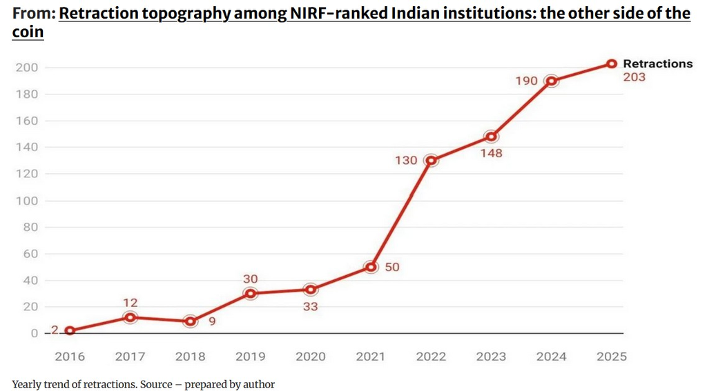

Retraction topography among NIRF-ranked Indian institutions. Yearly trend, source prepared by author.

## What you’ll be able to do

By the end of these 30 minutes:

1. **Recognise** the forms of plagiarism, including the ones that don’t feel like plagiarism.
2. **Read** your similarity report against the **UGC 2018** thresholds and journal rules.
3. **Apply** real paraphrasing, quoting and citing techniques to your own thesis & manuscripts.
4. **Navigate** the grey zones: self-plagiarism, “common knowledge”, methods text, and AI tools.

## What plagiarism actually is

> Presenting someone else’s **words or ideas** as your own, without attribution.

The half residents forget is **“or ideas.”** You can plagiarise without copying a single sentence.

Two axes that cause all the confusion:

- **Intent:** deliberate · reckless · *unintentional.* all three are penalised
- **Object:** text · data · images · ideas / structure

“I didn’t mean to” is **not a defence** under the UGC regulations.

## The taxonomy, from obvious to subtle

1. **Verbatim / copy-paste:** the obvious one.
2. **Mosaic / patchwork:** phrases stitched from several sources. *The most common resident error.*
3. **Close paraphrase:** change a few words, keep the structure. *Still plagiarism.*
4. **Idea / structure:** reuse an argument or framework, even fully reworded.
5. **Self-plagiarism & duplicate publication:** reusing your own text or data without disclosure (“salami slicing”).
6. **Citation plagiarism:** citing a paper you never read, copied from another’s reference list.

# Spot the plagiarism

Four real-world patterns. Reveal the verdict, then the fix.

## Example 1: Verbatim

**Source (published, 2019)**

“Anaemia in pregnancy remains a major public health challenge in India, contributing substantially to maternal morbidity and adverse perinatal outcomes.”

**In the resident’s manuscript**

Anaemia in pregnancy remains a major public health challenge in India, contributing substantially to maternal morbidity and adverse perinatal outcomes.

**Verdict: Plagiarism.** Word-for-word, no quotation marks, no citation. The similarity checker flags 100% of this sentence.

**Fix: paraphrase and cite**

In India, anaemia during pregnancy is a leading contributor to maternal illness and poor newborn outcomes.<sup>[12]</sup>

## Example 2: Mosaic / patchwork

**Two sources**

**A:** “…iron deficiency accounts for nearly half of all anaemia cases among pregnant women in low-income settings.”

**B:** “…weekly iron–folic acid supplementation has been shown to reduce the prevalence of moderate anaemia.”

**In the manuscript (one sentence, no marks)**

Iron deficiency accounts for nearly half of all anaemia cases among pregnant women, and weekly iron–folic acid supplementation has been shown to reduce the prevalence of moderate anaemia.

**Verdict: Plagiarism.** Distinctive phrases lifted verbatim from two sources and stitched together. Adding the two citations does **not** fix it; the *wording* is still copied.

**Fix: synthesise in your own words and cite both**

Roughly half of anaemia in pregnant women is attributable to iron deficiency,<sup>[5]</sup> and weekly iron–folic acid dosing can lower moderate-anaemia rates.<sup>[8]</sup>

## Example 3: Close paraphrase

**Source**

“Delayed initiation of antenatal care is strongly associated with poor pregnancy outcomes, particularly among women in rural and tribal communities.”

**In the manuscript (cited!)**

Late starting of antenatal care is highly linked with bad pregnancy results, especially among women in rural and tribal populations.<sup>[9]</sup>

**Verdict: Plagiarism.** Same sentence skeleton, synonyms swapped in slots. A citation does not rescue it. This is the classic “synonym-swap” failure, and modern checkers catch the structure.

**Fix: rewrite from understanding**

Women who book antenatal care late tend to have worse outcomes, and this gap is widest in rural and tribal areas.<sup>[9]</sup> *(Read it, look away, write it, then cite.)*

## Example 4: Self-plagiarism

**Your OWN earlier paper (2023)**

“We conducted a community-based cross-sectional survey across 12 sub-centres using a two-stage cluster sampling design; households were selected by probability proportional to size.”

**Pasted into the new manuscript, unchanged, no note**

We conducted a community-based cross-sectional survey across 12 sub-centres using a two-stage cluster sampling design; households were selected by probability proportional to size.

**Verdict: Self-plagiarism.** Reusing your *own* published text without disclosure. The checker matches it against your prior paper, and editors treat it as a red flag.

**Fix: rewrite and signpost the prior work**

The sampling and survey procedures followed those of our earlier study.<sup>[3]</sup> Briefly, households across 12 sub-centres were enrolled using two-stage cluster sampling with probability proportional to size.

## The Indian rulebook: UGC 2018

**UGC (Promotion of Academic Integrity & Prevention of Plagiarism in HEIs) Regulations, 2018** set out a *graded* penalty system based on your similarity index:

| Level | Similarity | Consequence (student / researcher; illustrative) |
| --- | --- | --- |
| **0** | ≤ 10% | Minor, **no penalty** |
| **1** | > 10–40% | Revise & resubmit (usually within 6 months) |
| **2** | > 40–60% | Debarred from resubmission for ~1 year |
| **3** | > 60% | Registration / programme can be **cancelled** |

Your **thesis submission** requires a similarity report (Turnitin / DrillBit–ShodhShuddhi). Journals run a **second, independent** check at submission (iThenticate / Crossref Similarity Check).

## Three myths that get residents into trouble

- **Myth: “Under 10% means I’m safe.”** 9% lifted verbatim from *one* source is still plagiarism. The index is a **screen, not an absolution.**
- **Myth: “My references and quotes count against me.”** A properly configured report **excludes** the bibliography and correctly quoted matter. Learn to read, and to set up, the report.
- **Myth: “My guide is responsible, not me.”** The UGC penalises the **author.** Supervisors carry *separate, additional* liability; it does not transfer off you.

## The toolkit: how to NOT plagiarise

- **Paraphrase by understanding:** read, look away, write, then cite. Never synonym-swap with the source open.
- **Quote sparingly:** only for distinctive wording, definitions, contested claims, with quotation marks **and** citation.
- **Cite ideas, not just words:** every borrowed *claim* gets a citation, even when fully reworded.
- **“Common-knowledge” test:** would any expert state this without a source? If unsure, **cite.**
- **Methods grey zone:** rewrite, cite your prior work, disclose: *“as previously described [ref].”*
- **Workflow hygiene:** reference manager (Zotero) from day one; tag verbatim notes instantly; run *your own* similarity check **before** you submit.

## The AI frontier, 2026

LLMs (ChatGPT and others) now both **write** and **get caught in** manuscripts. Journals flag tell-tale phrasing and fabricated references.

**Where policy stands (and it’s moving):**

- UGC has **not** issued definitive guidance yet.
- AICTE restricts **unacknowledged** AI use.
- Most institutions & journals now treat **undisclosed AI-generated text as misconduct.**
- ICMJE / COPE: **disclose** AI use; AI **cannot** be an author.

AI may *assist* (grammar, structure) with disclosure. It must never generate claims, data, or citations you haven’t verified.

# Three rules to leave with

Attribute everything borrowed.

Verify every reference.

Disclose every tool.

## Thank you · Questions

**Quick references for your desk:**

- UGC Regulations 2018, your institutional plagiarism policy & similarity-report SOP
- COPE flowcharts, what editors do when misconduct is suspected
- ICMJE Recommendations, authorship & AI-disclosure criteria

Run your own similarity check before submission, not after rejection.